# 0001_explore

## Background

I have a file of normalised expression values from AtGenExpress Affy ATH1 arrays abiotic stress set, a file of TF -> target interactions from [agris](https://agris-knowledgebase.org) and a set of Affy probe set to AGI locus mappings from [TAIR](http://arabidopsis.org). The TFs have been mapped to probesets and known, confirmed, direct interactions from agris used to be the basis of the positive training set. An equal number of randomly selected other pairs of probesets are used as negative training data. The expression value profiles for each pair are extracted as a training example, thus each training example is a tensor of dimension `(2,232)`, there are 8704 examples.

## Aim

Here we will load in the prepared Arabidopsis TF pair data and try to find a useful model structure.

I believe this to be a binary classification problem. As the training data has dimensions `(2,232)` convolution can’t be applied. Nor do the input tensors have any particular natural ordering on the x axis (actually there is some timecourse information here, but I think I’ll ignore it for now), as it jumps. Perhaps there is a way of incorporating it later. I’ll try a dense network to start with.

## Load data

Let’s load in the prepared Arabidopsis TF pair data and give it a shuffle - the data as loaded have all the positive examples at the front. We’ll want a random order.

```r
arab_data <- readRDS("../data/arab_TF.RDS")
new_order <- sample(1:8704)
shuffled_data <- list(
  x = arab_data$x[new_order,,],
  y = as.numeric(arab_data$y[new_order])
)
new_order[1]
```

```
## [1] 2766
```

## Set aside validation and training set

We’ll need 3 partitions of the data - train, validate (development) and test. I’ll use approx 80/10/10 % split, so 6900, 902, 902.

I need to reshape the data to fit the order expected by Keras.

```r
train_i <- 1:6900
val_i <- 6901:7802
test_i <- 7803:8704

x_train <- shuffled_data$x[train_i,,]
x_val <- shuffled_data$x[val_i,,]
x_test <- shuffled_data$x[test_i,,]

y_train <- shuffled_data$y[train_i]
y_val <- shuffled_data$y[val_i]
y_test <- shuffled_data$y[test_i]
```

## Build initial network

```r
model <- keras_model_sequential() %>%
  layer_dense(units = 64, activation = "relu", input_shape = c(2, 232))  %>%
  layer_dense(units = 64) %>%
  layer_dense(units = 16) %>%
  layer_flatten() %>%
  layer_dense(units = 1, activation = "sigmoid")

model %>% compile(
  optimizer = "rmsprop",
  loss = "binary_crossentropy",
  metrics = c("accuracy")
)

str(model)
```

```
## Model
## ___________________________________________________________________________
## Layer (type)                     Output Shape                  Param #
## ===========================================================================
## dense_1 (Dense)                  (None, 2, 64)                 14912
## ___________________________________________________________________________
## dense_2 (Dense)                  (None, 2, 64)                 4160
## ___________________________________________________________________________
## dense_3 (Dense)                  (None, 2, 16)                 1040
## ___________________________________________________________________________
## flatten_1 (Flatten)              (None, 32)                    0
## ___________________________________________________________________________
## dense_4 (Dense)                  (None, 1)                     33
## ===========================================================================
## Total params: 20,145
## Trainable params: 20,145
## Non-trainable params: 0
## ___________________________________________________________________________
```

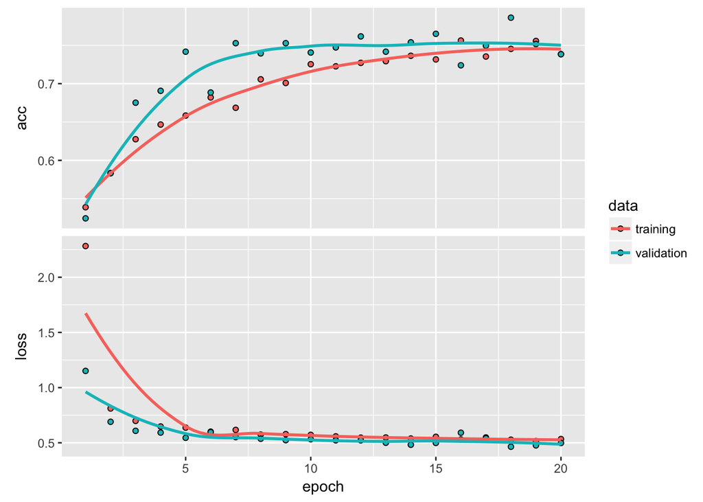

```r
history <- model %>% fit(
  x_train,
  y_train,
  epochs = 20,
  batch_size = 512,
  validation_data = list(x_val, y_val)
)

plot(history)
```

Not bad! A working network. I need to work out a good structure for these data.

## Explore model structure

```r
make_model <- function(layers=3, nodes_per_layer = 16 ){


  mod <- keras_model_sequential() %>%
    layer_dense(units = nodes_per_layer, activation = "relu", input_shape = c(2, 232))

  for (l in 2:layers){
    mod <-mod  %>%
      layer_dense(units = nodes_per_layer )
  }

  mod <-mod %>%
    layer_flatten() %>%
    layer_dense(units = 1, activation = "sigmoid")

  mod %>% compile(
    optimizer = "rmsprop",
    loss = "binary_crossentropy",
    metrics = c("accuracy")
  )

  mod
}


evaluate_model <- function(mod, x_train = NULL, y_train = NULL,
                           x_val = NULL, y_val = NULL,
                           epochs = 20, batch_size = 512,
                           verbose = 0){
  mod %>% fit(
    x_train,
    y_train,
    epochs = epochs,
    batch_size = batch_size,
    verbose = verbose
  )

  result <- model %>% evaluate(
    x_val,
    y_val,
    verbose = verbose
  )

  result$acc
}

model_accuracy <- function(x,
                           x_train = NULL, y_train = NULL,
                           x_val = NULL, y_val = NULL,
                           epochs = 20, batch_size = 512,
                           verbose = 0){
   layers <- as.integer(ceiling(x[1]))
   nodes_per_layer <- as.integer(ceiling(x[2]))
   #print(layers, nodes_per_layer)
   m <- make_model(layers = layers, nodes_per_layer = nodes_per_layer)
   evaluate_model(m,
                x_train = x_train, y_train = y_train,
                x_val = x_val, y_val = y_val,
                epochs = epochs, batch_size = batch_size,
                verbose = verbose
                )


}
search <- ga(type = "real-valued",
              fitness = model_accuracy,#  x_train = x_train, y_train = y_train, x_val = x_val, y_val = y_val),
              lower = c(4,4),
              upper = c(32,64),
              popSize = 50,
              maxiter = 10,
              run = 2,
              x_train = x_train, y_train = y_train, x_val = x_val, y_val = y_val
 )

 str(search)
```

```
## Formal class 'ga' [package "GA"] with 20 slots
##   ..@ call        : language ga(type = "real-valued", fitness = model_accuracy, x_train = x_train,      y_train = y_train, x_val = x_val, y_va| __truncated__ ...
##   ..@ type        : chr "real-valued"
##   ..@ lower       : num [1:2] 4 4
##   ..@ upper       : num [1:2] 32 64
##   ..@ nBits       : logi NA
##   ..@ names       : chr [1:2] "x1" "x2"
##   ..@ popSize     : num 50
##   ..@ iter        : int 2
##   ..@ run         : int 2
##   ..@ maxiter     : num 10
##   ..@ suggestions : logi[0 , 1:2]
##   ..@ population  : num [1:50, 1:2] 20.1 21.8 18.5 25.2 30.2 ...
##   ..@ elitism     : num 2
##   ..@ pcrossover  : num 0.8
##   ..@ pmutation   : num 0.1
##   ..@ fitness     : num [1:50] 0.738 0.738 0.738 0.738 0.738 ...
##   ..@ summary     : num [1:2, 1:6] 0.738 0.738 0.738 0.738 0.738 ...
##   .. ..- attr(*, "dimnames")=List of 2
##   .. .. ..$ : NULL
##   .. .. ..$ : chr [1:6] "max" "mean" "q3" "median" ...
##   ..@ bestSol     : list()
##   ..@ fitnessValue: num 0.738
##   ..@ solution    : num [1:50, 1:2] 20.1 21.8 18.5 25.2 30.2 ...
##   .. ..- attr(*, "dimnames")=List of 2
##   .. .. ..$ : NULL
##   .. .. ..$ : chr [1:2] "x1" "x2"
```

```r
 saveRDS(search, "srch.RDS")
#model_accuracy(c(64,8), x_train = x_train, y_train = y_train, x_val = x_val, y_val = y_val)
 # history <- m %>% fit(
 #   x_train,
 #   y_train,
 #   epochs = 20,
 #   batch_size = 512,
 #   validation_data = list(x_val, y_val)
 # )
 #
 # plot(history)
 # str(history)
 # summary(history)
```